# SAVI — marginalise unknown fixed effects (brms tuning)

Compare predict vs epred and marginalisation methods on universal healthy null

Published

08 Jun 2026

# Purpose

Minimal notebook to **tune marginalisation** of multiple unknown categorical fixed effects for gene-level Immune Atlas `brms` models under the **universal** healthy null (`offset = 0`, `tissue_groups = blood`, `disease_groups_altered = Normal`, other covariates `NA`).

Use **`brms_universal_null_draws()`** to switch:

- **`predict_type`**: `predict` (`posterior_predict`, observation noise) vs `epred` (`posterior_epred`, mean only)
- **`marginalize_method`**: `sample`, `mean`, `pool`, `hierarchical`

# Setup

```r
.libPaths("/hpcfs/users/a1237163/R/x86_64-pc-linux-gnu-library/4.5")

library(tibble)
library(tidyr)
library(dplyr)
library(purrr)
library(ggplot2)
library(SummarizedExperiment)
library(S4Vectors)
library(AnnotationDbi)
library(org.Hs.eg.db)
library(tidybulk)
library(brms)
library(poco)
library(targets)
library(Seurat)
library(tidyseurat)
library(tidySingleCellExperiment)
library(tidySummarizedExperiment)
library(progressr)
```

```r
set.seed(params$seed)

hierarchical_order <- params$hierarchical_order

marginalize_methods <- c("sample", "mean", "pool")

method_grid <- tidyr::crossing(
  predict_type = c("predict", "epred"),
  marginalize_method = marginalize_methods
) |>
  dplyr::mutate(
    method_label = paste(.data$predict_type, .data$marginalize_method, sep = " · ")
  )

method_grid
```

| predict_type | marginalize_method | method_label |
| --- | --- | --- |
| epred | mean | epred · mean |
| epred | pool | epred · pool |
| epred | sample | epred · sample |
| predict | mean | predict · mean |
| predict | pool | predict · pool |
| predict | sample | predict · sample |

# Generic marginalisation API

```r
fit_levels <- function(fit, var) {
  d <- fit$data
  if (is.null(d) || !var %in% names(d)) return(character(0))
  v <- d[[var]]
  lv <- if (is.factor(v)) levels(v) else sort(unique(as.character(v)))
  lv[!is.na(lv) & nzchar(lv)]
}

universal_baseline_new_level_tag <- "__universal_baseline__"

newdata_universal_baseline <- function() {
  tibble::tibble(
    age_decade = NA_character_,
    sex = NA_character_,
    ethnicity_groups = NA_character_,
    assay_groups_altered = NA_character_,
    disease_groups_altered = "Normal",
    tissue_groups = "blood",
    offset = 0
  )
}

build_newdata_grid <- function(
  fit,
  newdata,
  marginalize_over = c("sex", "age_decade", "ethnicity_groups", "assay_groups_altered"),
  required = c("tissue_groups", "offset", "disease_groups_altered"),
  new_level_cols = "dataset_id_altered",
  new_level_tag = universal_baseline_new_level_tag
) {
  stopifnot(NROW(newdata) == 1L)
  newdata <- tibble::as_tibble(newdata)

  is_blank <- function(v) {
    length(v) == 0L ||
      is.na(v[[1L]]) ||
      (is.character(v[[1L]]) && !nzchar(v[[1L]]))
  }

  fit_vars <- colnames(fit$data)

  for (col in required) {
    if (!col %in% fit_vars) next
    if (!col %in% names(newdata) || is_blank(newdata[[col]])) {
      stop(sprintf("Required predictor `%s` is missing or empty in newdata.", col))
    }
  }

  to_expand <- character(0)
  for (col in marginalize_over) {
    if (!col %in% fit_vars) next
    if (!col %in% names(newdata) || is_blank(newdata[[col]])) {
      to_expand <- c(to_expand, col)
    }
  }

  if (length(to_expand)) {
    levels_list <- lapply(to_expand, function(col) fit_levels(fit, col))
    names(levels_list) <- to_expand
    keep <- vapply(levels_list, length, integer(1L)) > 0L
    levels_list <- levels_list[keep]
    to_expand <- names(levels_list)
  }

  if (length(to_expand)) {
    grid <- do.call(tidyr::expand_grid, levels_list)
    rest <- newdata[, setdiff(names(newdata), to_expand), drop = FALSE]
    out <- dplyr::bind_cols(
      rest[rep(1L, nrow(grid)), , drop = FALSE],
      grid
    )
  } else {
    out <- newdata
  }

  for (col in new_level_cols) {
    if (col %in% fit_vars) out[[col]] <- new_level_tag
  }

  tibble::as_tibble(out)
}

marginalize_draw_matrix <- function(
  y_mat,
  nd_grid,
  method = c("pool", "sample", "mean", "hierarchical"),
  hierarchical_order = c("age_decade", "assay_groups_altered", "ethnicity_groups", "sex")
) {
  method <- match.arg(method)
  if (is.null(dim(y_mat))) {
    return(as.numeric(y_mat))
  }
  if (ncol(y_mat) <= 1L) {
    return(as.numeric(y_mat))
  }

  switch(
    method,
    sample = {
      n <- nrow(y_mat)
      idx <- sample.int(ncol(y_mat), n, replace = TRUE)
      y_mat[cbind(seq_len(n), idx)]
    },
    mean = rowMeans(y_mat),
    pool = as.numeric(y_mat),
    hierarchical = {
      mat <- y_mat
      g <- tibble::as_tibble(nd_grid)
      for (fac in hierarchical_order) {
        if (!fac %in% names(g)) next
        if (ncol(mat) <= 1L) break
        if (dplyr::n_distinct(g[[fac]]) <= 1L) next

        group_cols <- setdiff(names(g), fac)
        if (!length(group_cols)) {
          mat <- matrix(rowMeans(mat), nrow = nrow(mat), ncol = 1L)
          break
        }

        grp_key <- interaction(g[group_cols], drop = TRUE, lex.order = FALSE)
        idx_list <- split(seq_len(ncol(mat)), grp_key)
        mat <- do.call(
          cbind,
          lapply(idx_list, function(idx) rowMeans(mat[, idx, drop = FALSE]))
        )
        g <- g |>
          dplyr::mutate(.grp = grp_key) |>
          dplyr::group_by(.grp) |>
          dplyr::slice(1L) |>
          dplyr::ungroup() |>
          dplyr::select(dplyr::all_of(group_cols))
      }

      if (ncol(mat) == 1L) as.numeric(mat) else rowMeans(mat)
    }
  )
}

#' Draw from universal healthy null with configurable marginalisation.
brms_universal_null_draws <- function(
  fit,
  newdata = newdata_universal_baseline(),
  predict_type = c("predict", "epred"),
  marginalize_method = c("pool", "sample", "mean", "hierarchical"),
  marginalize_over = c("sex", "age_decade", "ethnicity_groups", "assay_groups_altered"),
  required = c("tissue_groups", "offset", "disease_groups_altered"),
  new_level_cols = "dataset_id_altered",
  new_level_tag = universal_baseline_new_level_tag,
  hierarchical_order = c("age_decade", "assay_groups_altered", "ethnicity_groups", "sex"),
  re_formula = NULL,
  allow_new_levels = TRUE,
  sample_new_levels = "uncertainty",
  ndraws = NULL
) {
  predict_type <- match.arg(predict_type)
  marginalize_method <- match.arg(marginalize_method)

  nd_grid <- build_newdata_grid(
    fit,
    newdata,
    marginalize_over = marginalize_over,
    required = required,
    new_level_cols = new_level_cols,
    new_level_tag = new_level_tag
  )

  pred_fun <- switch(
    predict_type,
    predict = brms::posterior_predict,
    epred = brms::posterior_epred
  )

  y_mat <- pred_fun(
    fit,
    newdata = nd_grid,
    summary = FALSE,
    re_formula = re_formula,
    allow_new_levels = allow_new_levels,
    sample_new_levels = sample_new_levels,
    ndraws = ndraws
  )

  y_rep <- marginalize_draw_matrix(
    y_mat,
    nd_grid,
    method = marginalize_method,
    hierarchical_order = hierarchical_order
  )

  list(
    y_rep = y_rep,
    n_draws = length(y_rep),
    n_grid_rows = nrow(nd_grid),
    predict_type = predict_type,
    marginalize_method = marginalize_method
  )
}

gene_deviation_from_draws <- function(y_rep, obs, alpha = 0.025) {
  hpd <- if (requireNamespace("HDInterval", quietly = TRUE)) {
    HDInterval::hdi(y_rep, credMass = 0.95)
  } else {
    stats::quantile(
      y_rep,
      probs = c(0.025, 0.975),
      names = FALSE
    )
  }

  p_above <- mean(y_rep >= obs)
  p_below <- mean(y_rep <= obs)

  tibble::tibble(
    n_draws = length(y_rep),
    healthy_median = stats::median(y_rep),
    healthy_mean = mean(y_rep),
    healthy_sd = stats::sd(y_rep),
    healthy_hpd_lo = hpd[1],
    healthy_hpd_hi = hpd[2],
    healthy_hpd_width = hpd[2] - hpd[1],
    p_above_healthy = p_above,
    p_below_healthy = p_below,
    direction = dplyr::case_when(
      p_above < alpha ~ "higher_than_healthy",
      p_below < alpha ~ "lower_than_healthy",
      TRUE ~ "consistent_with_healthy"
    )
  )
}
```

# STING signature biomarkers (21 genes)

```r
sting_signature_21 <- tibble::tibble(
  gene = c(
    "AC253572.2", "ADRB2", "ANKRD28", "ANXA1", "AQP9", "AZIN1-AS1", "IL1B",
    "JARID2", "KLF4", "MIR4435-2HG", "OTUD1", "PLAUR", "PTGS2", "PTX3",
    "SELENOK", "TGIF1", "TREM1", "TSC22D2", "ZBTB43", "ZFP36L2", "ZNF503"
  )
) |>
  dplyr::mutate(
    .feature = AnnotationDbi::mapIds(
      org.Hs.eg.db::org.Hs.eg.db,
      keys = .data$gene,
      column = "ENSEMBL",
      keytype = "SYMBOL",
      multiVals = "first"
    )
  )

tibble::tibble(
  signature_genes = nrow(sting_signature_21),
  mapped_to_ensembl = sum(!is.na(sting_signature_21$.feature))
)
```

| signature_genes | mapped_to_ensembl |
| --- | --- |
| 21 | 19 |

# Data and fits (minimal)

```r
sting_estimates_chunk <- readRDS(params$estimates_rds)

tuning_fit_tbl <- sting_estimates_chunk |>
  dplyr::filter(
    .data$compression_ok == TRUE,
    lengths(.data$brms_fit_compressed) > 0L
  )

if (!nrow(tuning_fit_tbl)) {
  stop("No compressed biomarker fits in ", params$estimates_rds)
}

tuning_fit_tbl |>
  dplyr::select(.feature, gene, compression_ok)
```

| .feature | gene | compression_ok |
| --- | --- | --- |
| ENSG00000169252 | ADRB2 | TRUE |
| ENSG00000206560 | ANKRD28 | TRUE |
| ENSG00000135046 | ANXA1 | TRUE |
| ENSG00000103569 | AQP9 | TRUE |
| ENSG00000125538 | IL1B | TRUE |
| ENSG00000008083 | JARID2 | TRUE |
| ENSG00000136826 | KLF4 | TRUE |
| ENSG00000165312 | OTUD1 | TRUE |
| ENSG00000011422 | PLAUR | TRUE |
| ENSG00000073756 | PTGS2 | TRUE |

[output cut: 6 more lines]

```r
model_path <- file.path(
  params$model_store_root,
  paste0("V1_", params$target_cell_type)
)

SAVI_pseudobulk_sobj <- readRDS(params$savi_pseudobulk_rds) |>
  dplyr::filter(CellType == "17. Disease-associated monocytes")

pseudobulk_sample <- targets::tar_read(
  pseudobulk_sample,
  store = file.path(model_path, "_targets")
)

pseudobulk_sample@assays@data@listData[["counts"]]@seed@seed@seed@filepath <-
  params$pseudobulk_h5ad

ref_sample <- pseudobulk_sample |>
  dplyr::filter(offset == 0)

SummarizedExperiment::colData(ref_sample)$sample_role <- "reference"

counts_sym <- as.matrix(
  tryCatch(
    SeuratObject::LayerData(SAVI_pseudobulk_sobj, assay = "RNA", layer = "counts"),
    error = function(e) {
      Seurat::GetAssayData(SAVI_pseudobulk_sobj, assay = "RNA", slot = "counts")
    }
  )
)

sym <- rownames(counts_sym)
ensg <- AnnotationDbi::mapIds(
  org.Hs.eg.db::org.Hs.eg.db,
  keys = sym,
  column = "ENSEMBL",
  keytype = "SYMBOL",
  multiVals = "first"
)
keep <- !is.na(ensg) & !duplicated(ensg)
counts_ens <- counts_sym[keep, , drop = FALSE]
rownames(counts_ens) <- ensg[keep]

cd_savi <- as.data.frame(SAVI_pseudobulk_sobj@meta.data)
rownames(cd_savi) <- colnames(counts_ens)
cd_savi$sample_role <- "savi_pseudobulk"
cd_savi$offset <- 0L

se_savi <- SummarizedExperiment::SummarizedExperiment(
  assays = list(counts = counts_ens),
  colData = S4Vectors::DataFrame(cd_savi, row.names = colnames(counts_ens))
)

# Union colData columns before bind (SAVI Seurat meta != atlas reference cols).
merge_summarized_experiments <- function(...) {
  ses <- list(...)
  assay_names <- Reduce(intersect, lapply(ses, SummarizedExperiment::assayNames))
  if (length(assay_names) == 0L) {
    stop("No shared assays between SummarizedExperiment objects.")
  }

  genes <- Reduce(intersect, lapply(ses, rownames))
  if (length(genes) == 0L) {
    stop("No shared rownames between SummarizedExperiment objects.")
  }

  ses <- lapply(ses, function(se) se[genes, , drop = FALSE])

  cds <- lapply(ses, function(se) as.data.frame(SummarizedExperiment::colData(se)))
  all_nms <- Reduce(union, lapply(cds, names))
  cds <- lapply(cds, function(cd) {
    missing <- setdiff(all_nms, names(cd))
    for (nm in missing) {
      cd[[nm]] <- NA
    }
    cd[, all_nms, drop = FALSE]
  })

  assays <- stats::setNames(
    lapply(assay_names, function(an) {
      mats <- lapply(ses, function(se) {
        base::as.matrix(SummarizedExperiment::assay(se, an))
      })
      do.call(base::cbind, mats)
    }),
    assay_names
  )

  SummarizedExperiment::SummarizedExperiment(
    assays = assays,
    colData = S4Vectors::DataFrame(
      do.call(rbind, cds),
      row.names = unlist(lapply(ses, colnames), use.names = FALSE)
    ),
    rowData = SummarizedExperiment::rowData(ses[[1]])
  )
}

se_monocytic <- merge_summarized_experiments(se_savi, ref_sample)

ref_sample_name <- se_monocytic |>
  SummarizedExperiment::colData() |>
  as.data.frame() |>
  dplyr::filter(.data$sample_role == "reference") |>
  tibble::rownames_to_column("sample") |>
  dplyr::slice(1) |>
  dplyr::pull(sample)

se_monocytic <- se_monocytic |>
  tidybulk::scale_abundance(
    method = "TMMwsp",
    reference_sample = ref_sample_name
  ) |>
  dplyr::mutate(offset = log(1 / multiplier))

sample_annotations <- SummarizedExperiment::colData(se_monocytic) |>
  as.data.frame() |>
  tibble::rownames_to_column("sample") |>
  dplyr::filter(.data$sample_role == "savi_pseudobulk") |>
  dplyr::select("sample", tidyselect::any_of(c("Sample", "Category"))) |>
  dplyr::distinct() |>
  dplyr::filter(.data$Category == "SAVI") |>
  dplyr::select("sample", tidyselect::any_of(c("Sample", "Category")))

tuning_fit_tbl <- tuning_fit_tbl |>
  dplyr::filter(.data$.feature %in% rownames(se_monocytic))

biomarker_gene_order <- sting_signature_21$gene |>
  unique() %>%
  .[. %in% tuning_fit_tbl$gene]

biomarker_gene_order <- c(
  biomarker_gene_order,
  setdiff(tuning_fit_tbl$gene, biomarker_gene_order)
)

tuning_fit_tbl <- tuning_fit_tbl |>
  dplyr::mutate(
    gene = factor(.data$gene, levels = biomarker_gene_order)
  ) |>
  dplyr::arrange(.data$gene) |>
  dplyr::mutate(gene = as.character(.data$gene))

tibble::tibble(
  n_genes_tuning = nrow(tuning_fit_tbl),
  n_methods = nrow(method_grid),
  n_savi_samples = nrow(sample_annotations),
  n_savi_gene_tests_per_method = nrow(tuning_fit_tbl) * nrow(sample_annotations)
)
```

| n_genes_tuning | n_methods | n_savi_samples | n_savi_gene_tests_per_method |
| --- | --- | --- | --- |
| 16 | 6 | 5 | 80 |

# Run method grid

```r
run_null_for_gene_method <- function(gene_sym, method_row) {
  chunk <- tuning_fit_tbl |>
    dplyr::filter(.data$gene == .env$gene_sym) |>
    dplyr::slice(1)

  fit <- poco::reconstruct_brmsfit(chunk$brms_fit_compressed[[1]])

  baseline <- brms_universal_null_draws(
    fit,
    predict_type = method_row$predict_type,
    marginalize_method = method_row$marginalize_method,
    hierarchical_order = hierarchical_order,
    ndraws = params$ndraws
  )

  tibble::tibble(
    gene = gene_sym,
    .feature = chunk$.feature,
    method_label = method_row$method_label,
    predict_type = method_row$predict_type,
    marginalize_method = method_row$marginalize_method,
    n_grid_rows = baseline$n_grid_rows,
    draws = list(baseline$y_rep)
  )
}

with_progress({
  p <- progressr::progressor(
    steps = nrow(tuning_fit_tbl) * nrow(method_grid)
  )

  tuning_null_store <- purrr::pmap_dfr(
    tidyr::crossing(
      gene = tuning_fit_tbl$gene,
      method_idx = seq_len(nrow(method_grid))
    ),
    function(gene, method_idx) {
      p()
      run_null_for_gene_method(gene, method_grid[method_idx, ])
    }
  )
})

tuning_null_long <- tuning_null_store |>
  tidyr::unnest(tidyselect::all_of("draws")) |>
  dplyr::rename(value = draws) |>
  dplyr::mutate(
    method_label = factor(
      .data$method_label,
      levels = method_grid$method_label
    )
  )

tuning_null_store |>
  dplyr::distinct(.data$gene, .data$method_label, .data$n_grid_rows) |>
  dplyr::arrange(.data$gene, .data$method_label)
```

| gene | method_label | n_grid_rows |
| --- | --- | --- |
| ADRB2 | epred · mean | 840 |
| ADRB2 | epred · pool | 840 |
| ADRB2 | epred · sample | 840 |
| ADRB2 | predict · mean | 840 |
| ADRB2 | predict · pool | 840 |
| ADRB2 | predict · sample | 840 |
| ANKRD28 | epred · mean | 840 |
| ANKRD28 | epred · pool | 840 |
| ANKRD28 | epred · sample | 840 |
| ANKRD28 | predict · mean | 840 |

[output cut: 86 more lines]

# Summary metrics (tail tests vs `counts_scaled`, SAVI donors only)

**`tuning_summary`** compares the **SAVI-group median** per gene to each marginalised null. Per-donor tests are in **`tuning_sample_deviation`**; aggregated SAVI stats in **`tuning_savi_against_baseline`**.

```r
tuning_obs <- purrr::pmap_dfr(
  tuning_fit_tbl[c("gene", ".feature")],
  function(gene, .feature) {
    idx <- match(
      sample_annotations$sample,
      colnames(se_monocytic)
    )

    purrr::map_dfr(seq_along(idx), function(i) {
      obs <- SummarizedExperiment::assay(
        se_monocytic[.feature, idx[i], drop = FALSE],
        "counts_scaled"
      ) |>
        as.numeric()

      tibble::tibble(
        gene = gene,
        sample = sample_annotations$sample[i],
        observed_scaled = obs
      )
    })
  }
)

tuning_summary <- purrr::map_dfr(
  seq_len(nrow(tuning_null_store)),
  function(i) {
    row <- tuning_null_store[i, ]
    obs_savi_med <- tuning_obs |>
      dplyr::filter(.data$gene == row$gene) |>
      dplyr::pull(.data$observed_scaled) |>
      stats::median(na.rm = TRUE)

    gene_deviation_from_draws(row$draws[[1L]], obs = obs_savi_med) |>
      dplyr::mutate(
        gene = row$gene,
        .feature = row$.feature,
        method_label = row$method_label,
        predict_type = row$predict_type,
        marginalize_method = row$marginalize_method,
        n_grid_rows = row$n_grid_rows,
        obs_median_savi = obs_savi_med,
        .before = 1L
      )
  }
) |>
  dplyr::arrange(.data$gene, .data$healthy_hpd_width)

tuning_summary |>
  dplyr::count(.data$method_label, .data$direction)
```

| method_label | direction | n |
| --- | --- | --- |
| epred · mean | consistent_with_healthy | 16 |
| epred · pool | consistent_with_healthy | 16 |
| epred · sample | consistent_with_healthy | 16 |
| predict · mean | consistent_with_healthy | 16 |
| predict · pool | consistent_with_healthy | 16 |
| predict · sample | consistent_with_healthy | 16 |

# Narrowest healthy null per gene

```r
tuning_narrowest_hpd <- tuning_summary |>
  dplyr::group_by(.data$gene) |>
  dplyr::slice_min(.data$healthy_hpd_width, n = 1, with_ties = FALSE) |>
  dplyr::ungroup() |>
  dplyr::transmute(
    gene,
    narrowest_method = .data$method_label,
    predict_type,
    marginalize_method,
    healthy_hpd_width,
    healthy_hpd_lo,
    healthy_hpd_hi,
    n_draws,
    n_grid_rows,
    obs_median_savi,
    p_above_healthy,
    p_below_healthy,
    direction
  ) |>
  dplyr::arrange(.data$gene)

tuning_narrowest_hpd
```

| gene | narrowest_method | predict_type | marginalize_method | healthy_hpd_width | healthy_hpd_lo | healthy_hpd_hi | n_draws | n_grid_rows | obs_median_savi | p_above_healthy | p_below_healthy | direction |
| --- | --- | --- | --- | --- | --- | --- | --- | --- | --- | --- | --- | --- |
| ADRB2 | predict · pool | predict | pool | 2877.000 | 0.000000e+00 | 2877.000 | 336000 | 840 | 148.6646 | 0.25043750 | 0.7495625 | consistent_with_healthy |
| ANKRD28 | predict · pool | predict | pool | 2122.000 | 0.000000e+00 | 2122.000 | 336000 | 840 | 2630.9667 | 0.04466964 | 0.9553304 | consistent_with_healthy |
| ANXA1 | epred · pool | epred | pool | 13300.989 | 5.318993e-08 | 13300.989 | 336000 | 840 | 11663.9749 | 0.05737202 | 0.9426280 | consistent_with_healthy |
| AQP9 | predict · pool | predict | pool | 2750.000 | 0.000000e+00 | 2750.000 | 336000 | 840 | 1251.2602 | 0.07865476 | 0.9213452 | consistent_with_healthy |
| IL1B | predict · sample | predict | sample | 11600.000 | 0.000000e+00 | 11600.000 | 400 | 840 | 779.7250 | 0.27250000 | 0.7275000 | consistent_with_healthy |
| JARID2 | predict · sample | predict | sample | 9007.000 | 0.000000e+00 | 9007.000 | 400 | 840 | 5964.5975 | 0.08000000 | 0.9200000 | consistent_with_healthy |
| KLF4 | epred · sample | epred | sample | 7009.806 | 2.036922e-01 | 7010.010 | 400 | 840 | 13775.5333 | 0.03750000 | 0.9625000 | consistent_with_healthy |
| OTUD1 | predict · sample | predict | sample | 2421.000 | 0.000000e+00 | 2421.000 | 400 | 840 | 1963.6113 | 0.06500000 | 0.9350000 | consistent_with_healthy |
| PLAUR | predict · pool | predict | pool | 18764.000 | 0.000000e+00 | 18764.000 | 336000 | 840 | 5758.4922 | 0.12426786 | 0.8757321 | consistent_with_healthy |
| PTGS2 | predict · pool | predict | pool | 2553.000 | 0.000000e+00 | 2553.000 | 336000 | 840 | 1777.3124 | 0.06415179 | 0.9358482 | consistent_with_healthy |

[output cut: 6 more lines]

```r
tuning_narrowest_hpd |>
  dplyr::count(
    .data$narrowest_method,
    .data$predict_type,
    .data$marginalize_method,
    name = "n_genes"
  ) |>
  dplyr::arrange(dplyr::desc(.data$n_genes), .data$narrowest_method)
```

| narrowest_method | predict_type | marginalize_method | n_genes |
| --- | --- | --- | --- |
| predict · pool | predict | pool | 8 |
| predict · sample | predict | sample | 5 |
| epred · sample | epred | sample | 2 |
| epred · pool | epred | pool | 1 |

```r
make_tuning_summary_wide <- function(df) {
  df |>
    dplyr::select(
      gene,
      obs_median_savi,
      method_label,
      n_draws,
      n_grid_rows,
      healthy_hpd_width,
      p_above_healthy,
      p_below_healthy,
      direction
    ) |>
    tidyr::pivot_wider(
      id_cols = c(gene, obs_median_savi),
      names_from = method_label,
      values_from = c(
        healthy_hpd_width,
        p_above_healthy,
        p_below_healthy,
        direction
      ),
      names_sep = " | "
    )
}

make_tuning_summary_wide(tuning_summary)
```

| gene | obs_median_savi | healthy_hpd_width \| predict · pool | healthy_hpd_width \| predict · sample | healthy_hpd_width \| epred · pool | healthy_hpd_width \| epred · sample | healthy_hpd_width \| epred · mean | healthy_hpd_width \| predict · mean | p_above_healthy \| predict · pool | p_above_healthy \| predict · sample | p_above_healthy \| epred · pool | p_above_healthy \| epred · sample | p_above_healthy \| epred · mean | p_above_healthy \| predict · mean | p_below_healthy \| predict · pool | p_below_healthy \| predict · sample | p_below_healthy \| epred · pool | p_below_healthy \| epred · sample | p_below_healthy \| epred · mean | p_below_healthy \| predict · mean | direction \| predict · pool | direction \| predict · sample | direction \| epred · pool | direction \| epred · sample | direction \| epred · mean | direction \| predict · mean |
| --- | --- | --- | --- | --- | --- | --- | --- | --- | --- | --- | --- | --- | --- | --- | --- | --- | --- | --- | --- | --- | --- | --- | --- | --- | --- |
| ADRB2 | 148.6646 | 2877 | 4738 | 12970.215 | 18694.213 | 1618674.27 | 3804471.63 | 0.25043750 | 0.2450 | 0.50267262 | 0.4425 | 0.9025 | 0.9175 | 0.7495625 | 0.7550 | 0.4973274 | 0.5575 | 0.0975 | 0.0825 | consistent_with_healthy | consistent_with_healthy | consistent_with_healthy | consistent_with_healthy | consistent_with_healthy | consistent_with_healthy |
| ANKRD28 | 2630.9667 | 2122 | 2575 | 2760.386 | 2279.530 | 53347787.11 | 10086344.89 | 0.04466964 | 0.0475 | 0.05119940 | 0.0450 | 0.3250 | 0.3250 | 0.9553304 | 0.9525 | 0.9488006 | 0.9550 | 0.6750 | 0.6750 | consistent_with_healthy | consistent_with_healthy | consistent_with_healthy | consistent_with_healthy | consistent_with_healthy | consistent_with_healthy |
| ANXA1 | 11663.9749 | 16156 | 20976 | 13300.989 | 14061.214 | 412144.35 | 692875.09 | 0.07027381 | 0.0825 | 0.05737202 | 0.0625 | 0.2300 | 0.2250 | 0.9297262 | 0.9175 | 0.9426280 | 0.9375 | 0.7700 | 0.7750 | consistent_with_healthy | consistent_with_healthy | consistent_with_healthy | consistent_with_healthy | consistent_with_healthy | consistent_with_healthy |
| AQP9 | 1251.2602 | 2750 | 3656 | 10372.951 | 9081.912 | 454931.21 | 383645.81 | 0.07865476 | 0.0750 | 0.16624107 | 0.1375 | 0.4650 | 0.4475 | 0.9213452 | 0.9250 | 0.8337589 | 0.8625 | 0.5350 | 0.5525 | consistent_with_healthy | consistent_with_healthy | consistent_with_healthy | consistent_with_healthy | consistent_with_healthy | consistent_with_healthy |
| IL1B | 779.7250 | 17790 | 11600 | 34920.521 | 40359.008 | 845535.95 | 2061718.66 | 0.24493750 | 0.2725 | 0.38241667 | 0.3875 | 0.7425 | 0.7750 | 0.7550625 | 0.7275 | 0.6175833 | 0.6125 | 0.2575 | 0.2250 | consistent_with_healthy | consistent_with_healthy | consistent_with_healthy | consistent_with_healthy | consistent_with_healthy | consistent_with_healthy |
| JARID2 | 5964.5975 | 11848 | 9007 | 11386.191 | 12412.530 | 1015314.34 | 222953.00 | 0.08897619 | 0.0800 | 0.08746726 | 0.0900 | 0.2875 | 0.2700 | 0.9110238 | 0.9200 | 0.9125327 | 0.9100 | 0.7125 | 0.7300 | consistent_with_healthy | consistent_with_healthy | consistent_with_healthy | consistent_with_healthy | consistent_with_healthy | consistent_with_healthy |
| KLF4 | 13775.5333 | 11612 | 9345 | 10859.022 | 7009.806 | 407725.59 | 1032656.28 | 0.04545536 | 0.0400 | 0.04292262 | 0.0375 | 0.1825 | 0.1975 | 0.9545446 | 0.9600 | 0.9570774 | 0.9625 | 0.8175 | 0.8025 | consistent_with_healthy | consistent_with_healthy | consistent_with_healthy | consistent_with_healthy | consistent_with_healthy | consistent_with_healthy |
| OTUD1 | 1963.6113 | 2782 | 2421 | 3957.862 | 4780.113 | 221730.27 | 279809.45 | 0.06465476 | 0.0650 | 0.08564881 | 0.0975 | 0.2800 | 0.2650 | 0.9353452 | 0.9350 | 0.9143512 | 0.9025 | 0.7200 | 0.7350 | consistent_with_healthy | consistent_with_healthy | consistent_with_healthy | consistent_with_healthy | consistent_with_healthy | consistent_with_healthy |
| PLAUR | 5758.4922 | 18764 | 24527 | 19465.462 | 21903.178 | 1543778.58 | 1271833.60 | 0.12426786 | 0.1250 | 0.13298810 | 0.1500 | 0.4675 | 0.4625 | 0.8757321 | 0.8750 | 0.8670119 | 0.8500 | 0.5325 | 0.5375 | consistent_with_healthy | consistent_with_healthy | consistent_with_healthy | consistent_with_healthy | consistent_with_healthy | consistent_with_healthy |
| PTGS2 | 1777.3124 | 2553 | 3341 | 3259.247 | 3931.565 | 90504.03 | 103832.08 | 0.06415179 | 0.0675 | 0.07783631 | 0.0850 | 0.2050 | 0.2450 | 0.9358482 | 0.9325 | 0.9221637 | 0.9150 | 0.7950 | 0.7550 | consistent_with_healthy | consistent_with_healthy | consistent_with_healthy | consistent_with_healthy | consistent_with_healthy | consistent_with_healthy |

[output cut: 6 more lines]

```r
tuning_sample_deviation <- purrr::map_dfr(
  seq_len(nrow(tuning_null_store)),
  function(i) {
    row <- tuning_null_store[i, ]
    obs_gene <- tuning_obs |>
      dplyr::filter(.data$gene == row$gene)

    purrr::map_dfr(
      seq_len(nrow(obs_gene)),
      function(j) {
        obs_row <- obs_gene[j, ]
        gene_deviation_from_draws(
          row$draws[[1L]],
          obs = obs_row$observed_scaled
        ) |>
          dplyr::mutate(
            gene = row$gene,
            .feature = row$.feature,
            sample = obs_row$sample,
            observed_scaled = obs_row$observed_scaled,
            method_label = row$method_label,
            predict_type = row$predict_type,
            marginalize_method = row$marginalize_method,
            n_grid_rows = row$n_grid_rows,
            .before = 1L
          )
      }
    )
  }
)

tuning_sample_deviation |>
  dplyr::count(.data$method_label, .data$direction)
```

| method_label | direction | n |
| --- | --- | --- |
| epred · mean | consistent_with_healthy | 78 |
| epred · mean | lower_than_healthy | 2 |
| epred · pool | consistent_with_healthy | 75 |
| epred · pool | higher_than_healthy | 3 |
| epred · pool | lower_than_healthy | 2 |
| epred · sample | consistent_with_healthy | 75 |
| epred · sample | higher_than_healthy | 3 |
| epred · sample | lower_than_healthy | 2 |
| predict · mean | consistent_with_healthy | 78 |
| predict · mean | lower_than_healthy | 2 |

[output cut: 4 more lines]

```r
# Per SAVI donor × gene vs universal marginalised null.
tuning_savi_deviation <- tuning_sample_deviation

tuning_savi_against_baseline <- tuning_savi_deviation |>
  dplyr::group_by(
    .data$method_label,
    .data$predict_type,
    .data$marginalize_method
  ) |>
  dplyr::summarise(
    n_savi_donors = dplyr::n_distinct(.data$sample),
    n_gene_sample_tests = dplyr::n(),
    n_higher_than_healthy = sum(
      .data$direction == "higher_than_healthy",
      na.rm = TRUE
    ),
    n_lower_than_healthy = sum(
      .data$direction == "lower_than_healthy",
      na.rm = TRUE
    ),
    n_consistent_with_healthy = sum(
      .data$direction == "consistent_with_healthy",
      na.rm = TRUE
    ),
    pct_higher_than_healthy = 100 * .data$n_higher_than_healthy / .data$n_gene_sample_tests,
    pct_against_baseline = .data$pct_higher_than_healthy,
    pct_not_consistent = 100 * (
      1 - .data$n_consistent_with_healthy / .data$n_gene_sample_tests
    ),
    .groups = "drop"
  ) |>
  dplyr::arrange(dplyr::desc(.data$pct_against_baseline))

# Donor-level: SAVI samples with at least one biomarker elevated (per method).
tuning_savi_donor_against <- tuning_savi_deviation |>
  dplyr::group_by(.data$method_label, .data$sample) |>
  dplyr::summarise(
    n_genes_tested = dplyr::n(),
    n_genes_higher = sum(.data$direction == "higher_than_healthy", na.rm = TRUE),
    any_higher_than_healthy = .data$n_genes_higher > 0L,
    majority_higher = .data$n_genes_higher > (.data$n_genes_tested / 2),
    .groups = "drop"
  ) |>
  dplyr::group_by(.data$method_label) |>
  dplyr::summarise(
    n_savi_donors = dplyr::n(),
    n_donors_any_gene_higher = sum(.data$any_higher_than_healthy),
    pct_donors_any_gene_higher = 100 * .data$n_donors_any_gene_higher / .data$n_savi_donors,
    n_donors_majority_genes_higher = sum(.data$majority_higher),
    pct_donors_majority_genes_higher = 100 * .data$n_donors_majority_genes_higher / .data$n_savi_donors,
    .groups = "drop"
  ) |>
  dplyr::arrange(dplyr::desc(.data$pct_donors_any_gene_higher))

tuning_savi_against_baseline
```

| method_label | predict_type | marginalize_method | n_savi_donors | n_gene_sample_tests | n_higher_than_healthy | n_lower_than_healthy | n_consistent_with_healthy | pct_higher_than_healthy | pct_against_baseline | pct_not_consistent |
| --- | --- | --- | --- | --- | --- | --- | --- | --- | --- | --- |
| predict · pool | predict | pool | 5 | 80 | 5 | 0 | 75 | 6.25 | 6.25 | 6.25 |
| predict · sample | predict | sample | 5 | 80 | 4 | 0 | 76 | 5.00 | 5.00 | 5.00 |
| epred · pool | epred | pool | 5 | 80 | 3 | 2 | 75 | 3.75 | 3.75 | 6.25 |
| epred · sample | epred | sample | 5 | 80 | 3 | 2 | 75 | 3.75 | 3.75 | 6.25 |
| epred · mean | epred | mean | 5 | 80 | 0 | 2 | 78 | 0.00 | 0.00 | 2.50 |
| predict · mean | predict | mean | 5 | 80 | 0 | 2 | 78 | 0.00 | 0.00 | 2.50 |

```r
tuning_savi_deviation |>
  dplyr::group_by(.data$method_label, .data$gene) |>
  dplyr::summarise(
    n_savi_samples = dplyr::n(),
    n_higher = sum(.data$direction == "higher_than_healthy", na.rm = TRUE),
    pct_savi_higher = 100 * .data$n_higher / .data$n_savi_samples,
    .groups = "drop"
  ) |>
  dplyr::arrange(.data$method_label, dplyr::desc(.data$pct_savi_higher))
```

| method_label | gene | n_savi_samples | n_higher | pct_savi_higher |
| --- | --- | --- | --- | --- |
| epred · mean | ADRB2 | 5 | 0 | 0 |
| epred · mean | ANKRD28 | 5 | 0 | 0 |
| epred · mean | ANXA1 | 5 | 0 | 0 |
| epred · mean | AQP9 | 5 | 0 | 0 |
| epred · mean | IL1B | 5 | 0 | 0 |
| epred · mean | JARID2 | 5 | 0 | 0 |
| epred · mean | KLF4 | 5 | 0 | 0 |
| epred · mean | OTUD1 | 5 | 0 | 0 |
| epred · mean | PLAUR | 5 | 0 | 0 |
| epred · mean | PTGS2 | 5 | 0 | 0 |

[output cut: 86 more lines]

# Density grid (rows = parameter combos, cols = genes)

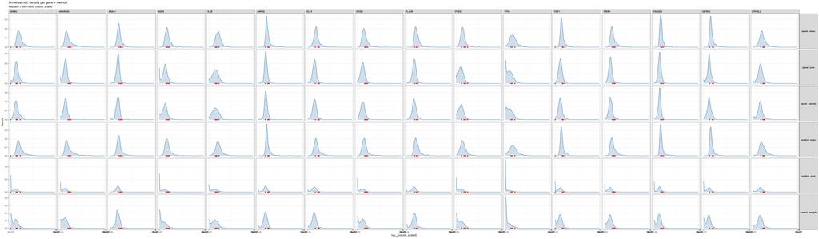

```r
log1p_count_trans <- scales::trans_new(
  name = "log1p",
  transform = function(x) log1p(pmax(x, 0)),
  inverse = function(x) expm1(x),
  domain = c(0, Inf)
)

category_cols <- c(SAVI = "#E41A1C")

gene_order <- biomarker_gene_order

tuning_null_plot <- tuning_null_long |>
  dplyr::filter(.data$gene %in% gene_order) |>
  dplyr::mutate(
    gene = factor(.data$gene, levels = gene_order),
    method_label = factor(.data$method_label, levels = method_grid$method_label)
  )

tuning_obs_plot <- tuning_obs |>
  dplyr::filter(.data$gene %in% gene_order) |>
  dplyr::mutate(gene = factor(.data$gene, levels = gene_order)) |>
  tidyr::crossing(
    method_label = factor(method_grid$method_label, levels = method_grid$method_label)
  )

ggplot2::ggplot() +
  ggplot2::geom_density(
    data = tuning_null_plot,
    ggplot2::aes(x = .data$value),
    fill = "steelblue",
    colour = "steelblue",
    alpha = 0.25,
    linewidth = 0.6,
    na.rm = TRUE
  ) +
  ggplot2::geom_point(
    data = tuning_obs_plot,
    ggplot2::aes(x = .data$observed_scaled, y = 0),
    colour = category_cols[["SAVI"]],
    shape = 16,
    size = 2,
    alpha = 0.85
  ) +
  ggplot2::facet_grid(
    method_label ~ gene,
    scales = "free_y"
  ) +
  ggplot2::scale_x_continuous(trans = log1p_count_trans) +
  ggplot2::labs(
    x = expression(log[1 + p](counts_scaled)),
    y = "Density",
    title = "Universal null: density per gene \u00d7 method",
    subtitle = "Red dots = SAVI donor counts_scaled"
  ) +
  ggplot2::theme_bw(base_size = 11) +
  ggplot2::theme(
    strip.text.y = ggplot2::element_text(angle = 0, face = "bold", size = 9),
    strip.text.x = ggplot2::element_text(angle = 0, face = "bold", size = 9, vjust = 0.5, hjust = 0),
    panel.spacing = ggplot2::unit(0.3, "lines")
  ) -> plot

print(plot)
```

# Random-effect tuning: `dataset_id_altered` handling

Five strategies for the unknown random effect (`dataset_id_altered`), with fixed FE marginalisation (`predict · pool`).

```r
re_known_dataset_id <- "9f222629-9e39-47d0-b83f-e08d610c7479"

re_grid <- tibble::tribble(
  ~re_label,              ~use_re_formula_na, ~dataset_id_value,                  ~allow_new_levels, ~sample_new_levels,
  "Known dataset",        FALSE,              re_known_dataset_id,                FALSE,             "uncertainty",
  "RE removed",           TRUE,               universal_baseline_new_level_tag,   FALSE,             "uncertainty",
  "New · uncertainty",    FALSE,              universal_baseline_new_level_tag,   TRUE,              "uncertainty",
  "New · gaussian",       FALSE,              universal_baseline_new_level_tag,   TRUE,              "gaussian",
  "New · old_levels",     FALSE,              universal_baseline_new_level_tag,   TRUE,              "old_levels"
)

re_grid
```

| re_label | use_re_formula_na | dataset_id_value | allow_new_levels | sample_new_levels |
| --- | --- | --- | --- | --- |
| Known dataset | FALSE | 9f222629-9e39-47d0-b83f-e08d610c7479 | FALSE | uncertainty |
| RE removed | TRUE | __universal_baseline__ | FALSE | uncertainty |
| New · uncertainty | FALSE | __universal_baseline__ | TRUE | uncertainty |
| New · gaussian | FALSE | __universal_baseline__ | TRUE | gaussian |
| New · old_levels | FALSE | __universal_baseline__ | TRUE | old_levels |

## Run RE grid

```r
run_null_for_gene_re <- function(gene_sym, re_row) {
  chunk <- tuning_fit_tbl |>
    dplyr::filter(.data$gene == .env$gene_sym) |>
    dplyr::slice(1)

  fit <- poco::reconstruct_brmsfit(chunk$brms_fit_compressed[[1]])

  re_formula_val <- if (re_row$use_re_formula_na) NA else NULL

  baseline <- brms_universal_null_draws(
    fit,
    predict_type      = "predict",
    marginalize_method = "pool",
    hierarchical_order = hierarchical_order,
    new_level_tag     = re_row$dataset_id_value,
    re_formula        = re_formula_val,
    allow_new_levels  = re_row$allow_new_levels,
    sample_new_levels = re_row$sample_new_levels,
    ndraws            = params$ndraws
  )

  tibble::tibble(
    gene             = gene_sym,
    .feature         = chunk$.feature,
    re_label         = re_row$re_label,
    n_grid_rows      = baseline$n_grid_rows,
    draws            = list(baseline$y_rep)
  )
}

re_label_levels <- re_grid$re_label

with_progress({
  p <- progressr::progressor(
    steps = nrow(tuning_fit_tbl) * nrow(re_grid)
  )

  re_null_store <- purrr::pmap_dfr(
    tidyr::crossing(
      gene   = tuning_fit_tbl$gene,
      re_idx = seq_len(nrow(re_grid))
    ),
    function(gene, re_idx) {
      p()
      run_null_for_gene_re(gene, re_grid[re_idx, ])
    }
  )
})

re_null_long <- re_null_store |>
  tidyr::unnest(tidyselect::all_of("draws")) |>
  dplyr::rename(value = draws) |>
  dplyr::mutate(
    re_label = factor(.data$re_label, levels = re_label_levels)
  )

re_null_store |>
  dplyr::distinct(.data$gene, .data$re_label, .data$n_grid_rows) |>
  dplyr::arrange(.data$gene, .data$re_label)
```

| gene | re_label | n_grid_rows |
| --- | --- | --- |
| ADRB2 | Known dataset | 840 |
| ADRB2 | New · gaussian | 840 |
| ADRB2 | New · old_levels | 840 |
| ADRB2 | New · uncertainty | 840 |
| ADRB2 | RE removed | 840 |
| ANKRD28 | Known dataset | 840 |
| ANKRD28 | New · gaussian | 840 |
| ANKRD28 | New · old_levels | 840 |
| ANKRD28 | New · uncertainty | 840 |
| ANKRD28 | RE removed | 840 |

[output cut: 70 more lines]

## RE summary metrics

```r
re_summary <- purrr::map_dfr(
  seq_len(nrow(re_null_store)),
  function(i) {
    row <- re_null_store[i, ]
    obs_savi_med <- tuning_obs |>
      dplyr::filter(.data$gene == row$gene) |>
      dplyr::pull(.data$observed_scaled) |>
      stats::median(na.rm = TRUE)

    gene_deviation_from_draws(row$draws[[1L]], obs = obs_savi_med) |>
      dplyr::mutate(
        gene         = row$gene,
        .feature     = row$.feature,
        re_label     = row$re_label,
        n_grid_rows  = row$n_grid_rows,
        obs_median_savi = obs_savi_med,
        .before = 1L
      )
  }
) |>
  dplyr::arrange(.data$gene, .data$healthy_hpd_width)

re_summary |>
  dplyr::count(.data$re_label, .data$direction)
```

| re_label | direction | n |
| --- | --- | --- |
| Known dataset | consistent_with_healthy | 16 |
| New · gaussian | consistent_with_healthy | 16 |
| New · old_levels | consistent_with_healthy | 16 |
| New · uncertainty | consistent_with_healthy | 16 |
| RE removed | consistent_with_healthy | 16 |

```r
re_sample_deviation <- purrr::map_dfr(
  seq_len(nrow(re_null_store)),
  function(i) {
    row <- re_null_store[i, ]
    obs_gene <- tuning_obs |>
      dplyr::filter(.data$gene == row$gene)

    purrr::map_dfr(
      seq_len(nrow(obs_gene)),
      function(j) {
        obs_row <- obs_gene[j, ]
        gene_deviation_from_draws(
          row$draws[[1L]],
          obs = obs_row$observed_scaled
        ) |>
          dplyr::mutate(
            gene            = row$gene,
            .feature        = row$.feature,
            sample          = obs_row$sample,
            observed_scaled = obs_row$observed_scaled,
            re_label        = row$re_label,
            n_grid_rows     = row$n_grid_rows,
            .before = 1L
          )
      }
    )
  }
)

re_sample_deviation |>
  dplyr::count(.data$re_label, .data$direction)
```

| re_label | direction | n |
| --- | --- | --- |
| Known dataset | consistent_with_healthy | 73 |
| Known dataset | higher_than_healthy | 7 |
| New · gaussian | consistent_with_healthy | 74 |
| New · gaussian | higher_than_healthy | 6 |
| New · old_levels | consistent_with_healthy | 73 |
| New · old_levels | higher_than_healthy | 7 |
| New · uncertainty | consistent_with_healthy | 75 |
| New · uncertainty | higher_than_healthy | 5 |
| RE removed | consistent_with_healthy | 72 |
| RE removed | higher_than_healthy | 8 |

```r
re_savi_against_baseline <- re_sample_deviation |>
  dplyr::group_by(.data$re_label) |>
  dplyr::summarise(
    n_savi_donors              = dplyr::n_distinct(.data$sample),
    n_gene_sample_tests        = dplyr::n(),
    n_higher_than_healthy      = sum(.data$direction == "higher_than_healthy", na.rm = TRUE),
    n_lower_than_healthy       = sum(.data$direction == "lower_than_healthy", na.rm = TRUE),
    n_consistent_with_healthy  = sum(.data$direction == "consistent_with_healthy", na.rm = TRUE),
    pct_higher_than_healthy    = 100 * .data$n_higher_than_healthy / .data$n_gene_sample_tests,
    pct_against_baseline       = .data$pct_higher_than_healthy,
    pct_not_consistent         = 100 * (1 - .data$n_consistent_with_healthy / .data$n_gene_sample_tests),
    .groups = "drop"
  ) |>
  dplyr::arrange(dplyr::desc(.data$pct_against_baseline))

re_savi_against_baseline
```

| re_label | n_savi_donors | n_gene_sample_tests | n_higher_than_healthy | n_lower_than_healthy | n_consistent_with_healthy | pct_higher_than_healthy | pct_against_baseline | pct_not_consistent |
| --- | --- | --- | --- | --- | --- | --- | --- | --- |
| RE removed | 5 | 80 | 8 | 0 | 72 | 10.00 | 10.00 | 10.00 |
| Known dataset | 5 | 80 | 7 | 0 | 73 | 8.75 | 8.75 | 8.75 |
| New · old_levels | 5 | 80 | 7 | 0 | 73 | 8.75 | 8.75 | 8.75 |
| New · gaussian | 5 | 80 | 6 | 0 | 74 | 7.50 | 7.50 | 7.50 |
| New · uncertainty | 5 | 80 | 5 | 0 | 75 | 6.25 | 6.25 | 6.25 |

## RE density grid (rows = RE strategy, cols = genes)

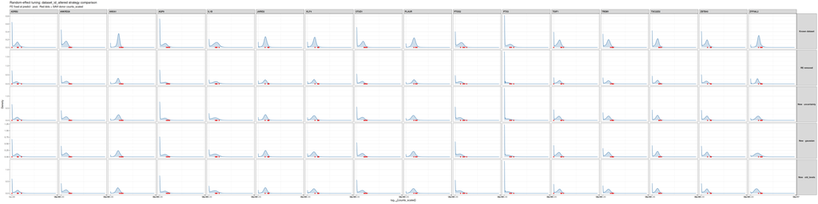

```r
re_null_plot <- re_null_long |>
  dplyr::filter(.data$gene %in% gene_order) |>
  dplyr::mutate(
    gene     = factor(.data$gene, levels = gene_order),
    re_label = factor(.data$re_label, levels = re_label_levels)
  )

re_obs_plot <- tuning_obs |>
  dplyr::filter(.data$gene %in% gene_order) |>
  dplyr::mutate(gene = factor(.data$gene, levels = gene_order)) |>
  tidyr::crossing(
    re_label = factor(re_label_levels, levels = re_label_levels)
  )

ggplot2::ggplot() +
  ggplot2::geom_density(
    data = re_null_plot,
    ggplot2::aes(x = .data$value),
    fill   = "steelblue",
    colour = "steelblue",
    alpha  = 0.25,
    linewidth = 0.6,
    na.rm  = TRUE
  ) +
  ggplot2::geom_point(
    data = re_obs_plot,
    ggplot2::aes(x = .data$observed_scaled, y = 0),
    colour = category_cols[["SAVI"]],
    shape  = 16,
    size   = 2,
    alpha  = 0.85
  ) +
  ggplot2::facet_grid(
    re_label ~ gene,
    scales = "free_y"
  ) +
  ggplot2::scale_x_continuous(trans = log1p_count_trans) +
  ggplot2::labs(
    x        = expression(log[1 + p](counts_scaled)),
    y        = "Density",
    title    = "Random-effect tuning: dataset_id_altered strategy comparison",
    subtitle = "FE fixed at predict \u00b7 pool.  Red dots = SAVI donor counts_scaled"
  ) +
  ggplot2::theme_bw(base_size = 11) +
  ggplot2::theme(
    strip.text.y  = ggplot2::element_text(angle = 0, face = "bold", size = 9),
    strip.text.x  = ggplot2::element_text(angle = 0, face = "bold", size = 9, vjust = 0.5, hjust = 0),
    panel.spacing = ggplot2::unit(0.3, "lines")
  ) -> re_plot

print(re_plot)
```

# Notes

## Fixed-effect marginalisation methods

| Method | Behaviour |
| --- | --- |
| **`sample`** | One random grid profile per MCMC draw (uniform discrete marginal). |
| **`mean`** | `rowMeans` over full grid per draw. |
| **`pool`** | Uniform mixture: all draw × grid values (`as.numeric(y_rep_mat)`; ~`ndraws` × `n_grid_rows` per gene). |

- **`hierarchical`** is available in the function API but not included in the tuning grid.
- Use **`predict_type = "predict"`** when comparing to observed **`counts_scaled`**.
- **`epred`** curves are on the mean scale — compare methods to each other, not directly to count points.
- **`pool`** is the heaviest method (e.g. 400 × 840 ≈ 336k draws per gene); subset genes in `tuning_fit_tbl` if render time or memory is tight.

## Random-effect (`dataset_id_altered`) strategies

| Strategy | `re_formula` | `dataset_id_altered` | `allow_new_levels` | `sample_new_levels` | Behaviour |
| --- | --- | --- | --- | --- | --- |
| **Known dataset** | `NULL` | real UUID | `FALSE` | — | Use a real-world dataset intercept to see how wide the baseline is for a known study. |
| **RE removed** | `NA` | — | — | — | Population-level prediction only; random effects excluded entirely. |
| **New · uncertainty** | `NULL` | new level | `TRUE` | `"uncertainty"` | Default: sample from existing levels with posterior uncertainty. |
| **New · gaussian** | `NULL` | new level | `TRUE` | `"gaussian"` | Model-based: a fresh dataset intercept drawn from N(0, sd_dataset_id_altered). |
| **New · old_levels** | `NULL` | new level | `TRUE` | `"old_levels"` | Reuse existing group-level effects by sampling from observed levels. |

## General

- **Against baseline** (`tuning-savi-against-baseline`): SAVI donors only; `pct_against_baseline` = % of biomarker × donor tests with `direction == higher_than_healthy` (also `pct_donors_any_gene_higher` = % of SAVI donors with ≥1 elevated gene).